# Lemurs

## Set Up

```r
library(tidyverse)
library(skimr)
library(patchwork)
library(cowplot)
library(ggridges)
```

## Import

```r
# use tidytuesdayR package to read 'taxonomy' data only
## parsing failure with lemurs data
taxonomy <- tidytuesdayR::tt_load(2021, week = 35, download_files = "taxonomy") %>% .$taxonomy
```

```
--- Compiling #TidyTuesday Information for 2021-08-24 ----
--- There are 2 files available ---
--- Starting Download ---
```

```
--- Download complete ---
```

```r
# read lemurs file sorting out parsing failure
lemurs <- readr::read_csv('https://raw.githubusercontent.com/rfordatascience/tidytuesday/master/data/2021/2021-08-24/lemur_data.csv',
                          col_types = cols(
                            age_of_living_y = col_double()))
```

## Tidying and Transformation

### Join datasets

Join both datasets so can use ‘common names’ rather than ‘taxon’ codes. First attempt resulted in missing values so I explored and corrected the differences between the two sets of data and re_joined them.

```r
# need to explore taxonomy dataset and look for error ?taxon codes that don't match
anti_join(lemurs, taxonomy) %>%
  distinct(taxon) %>% .$taxon
```

```
[1] "CMED"
```

```r
# taxon = "CMED" in one set "CMEAD" in the other --> NA when left join
# recode so these match
taxonomy$taxon <-
  taxonomy$taxon %>%
  fct_recode(CMED = "CMEAD")

# join both datasets so can use common names rather than 'taxon' codes
lemurs <- lemurs %>%
  left_join(taxonomy) %>%
  select(common_name, everything())
```

### Single row for each individual lemur

Grouped together data for each individual lemur so each lemur is represented by a single row. Multiple rows exist due to weight data for different ages. Can use original dataset to look at weight data and this new data_frame to look at individual lemurs.

There are 2 different hybrid species both coded as ‘hybrid’ so they are joined together when grouping by ‘common’ name. This distorts the data so I chose to exclude hybrid species from my analysis.

```r
lemurs_distinct <- distinct(lemurs, dlc_id, .keep_all = TRUE) %>%
  filter(common_name != "hybrid")
```

### Choose top species

There are 27 different species which will make comparisons difficult when visualising.

Create new object - a data-frame containing data for the *n* commonest species.

```r
n <- 5

top_species <- lemurs_distinct %>%
  group_by(common_name) %>%
  count() %>%
  arrange(desc(n)) %>%
  head(n) %>%
  pull(common_name)

top_species<- lemurs_distinct %>%
  filter(common_name %in% top_species)

rm(n)
```

## Visualisation

#### Age at death

Filter for those with known dob and known dod. This is to ensure accurate data. These are all captive born so data only represents captive born lemurs

```r
life_exp <- top_species %>%
  filter(!is.na(dob) & !is.na(dod) & is.na(estimated_dob))
```

### Generic settings

```r
lemur_pal <- c("#595a55", "#6e5337", "#948255", "#46413d", "#e2dcc4")

mean_age <- mean(life_exp$age_at_death_y) %>% round(2)

life_exp <- life_exp %>%
  mutate(common_name = fct_reorder(common_name, age_at_death_y))
```

### Individual plots

[figure not shown]

[figure not shown]

```r
box1 <- life_exp %>%
  mutate(common_name =
           fct_relabel(life_exp$common_name,
                       ~ str_replace(.x,"lemur", ""))) %>%
  ggplot()+
  geom_boxplot(aes(x = common_name, y = age_at_death_y,
                   fill = common_name))+
  coord_flip()+
  scale_fill_manual("Type of lemur", values = lemur_pal)+
  labs(x = NULL, y = NULL)+
  scale_x_discrete(breaks = NULL, labels = NULL)+
  theme_minimal_grid()+
  theme(legend.position = "right")+
  guides(fill = guide_legend(reverse = TRUE))
```

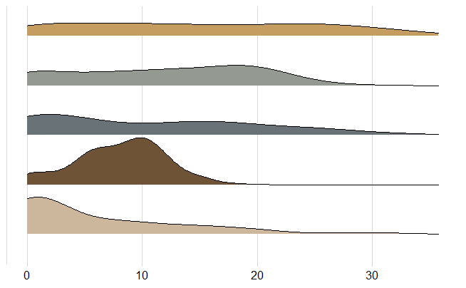

```r
ridge1 <- life_exp %>%
    ggplot()+
    geom_density_ridges(aes(x = age_at_death_y,
                            y = common_name,
                            height = ..density..,
                            fill = common_name,
                            scale = 0.95),
                        stat = "density") +
  scale_fill_manual(values = lemur_pal)+
  labs(x = NULL, y = NULL)+
  scale_y_discrete(breaks = NULL,
                       labels = NULL)+
  theme_minimal_vgrid()+
  theme(legend.position = "none")


ridge1
```

```r
NA
```

### Grouped plot using patchwork

```r
grouped_plot <- hist1 / (box1 + ridge1) + plot_annotation(
  title = "More lemurs  die in first year of life than at any other age\n(Top 5 captive species at Duke Lemur Centre)",
  subtitle = "Appears to be mainly due to deaths of Coquerel's Sifakas",
  caption = "Data: Tidy Tuesday | Plot: dataGP_UK")

grouped_plot
```

[output not shown]

### Save image

```r
ggsave(filename = "2018_08_24_Lemurs/plot1.png", width = 10, height = 6)
```